# COVID-19 Reddit Algo-Tracker

**How do Reddit’s popularity algorithms promote information about COVID-19?**

[figure not shown]

Since 2016, the [Citizens and Technology Lab](https://citizensandtech.org/about-cat-lab/) (CAT Lab) has taken ongoing snapshots of reddit’s algorithms every 2-3 minutes. We created this dashboard to inform the design of our collaborations with reddit communities on COVID-19 public health research.

During a pandemic, people need evolving information to guide our health decisions and what we share with others. These needs continue across the months-long [pandemic cycle of prevention, resilience, and recovery](https://www.ncbi.nlm.nih.gov/pmc/articles/PMC4504362/).

Reddit is already a major hub of COVID-19 information for hundreds of millions worldwide. News and norms spread rapidly across the site, promoted by people and algorithms. Reddit memes, jokes, and ideas are also shared widely on other platforms. While the reddit ecosystem could be a powerful force for good, public health experts have also argued that [cascades of human and algorithm sharing are the biggest pandemic risk](https://www.nature.com/articles/d41586-018-07034-4).

One reason to monitor algorithms is that information interventions can have unexpected side-effects on ranking algorithms. In a large-scale experiment with r/worldnews on reddit, I found that [encouraging fact-checking influenced what reddit’s popularity algorithms promoted by influencing human behavior](https://osf.io/m98b6/).

## How We Collect Data

[figure not shown]

- snapshots every 2 minutes of two key reddit algorithms:
  - reddit’s HOT algorithm, the default popularity ranking on the site
  - reddit’s TOP algorithm
- data about posts, currently queried from Jason Baumgartner’s [PushShift service](https://pushshift.io/)

With every report, this software also publishes research-quality datasets to [covid-algotracker on github](https://github.com/natematias/covid-algotracker/tree/master/data-archive/reddit), along with information about the settings, keywords, and software behind the data.

## How We Identify COVID-19 Posts

This report identified a post as related to COVID-19 if the lower-case title or the text of the submission matched any of the following English language terms ([code here](https://github.com/natematias/covid-algotracker/blob/master/scripts/fetch-reddit-frontpage.py)). Terms will be updated as the pandemic evolves.

```
##  [1] "coronavirus"      "covid"            "corona"           "wuhan"
##  [5] "pandemic"         "outbreak"         "epidemic"         "cdc"
##  [9] "social distanc"   "self-isolate"     "isolation"        "self isolate"
## [13] "quarantine"       "sanitizer"        "toilet paper"     "tp"
## [17] "wipes"            "world health"     "community spread" "herd immunity"
## [21] "respirators"      "shelter in place" "lockdown"         "n95"
## [25] "n-95"             "work from home"   "virus"            "ventilator"
```

# How Algorithms Promote Reddit Posts Over Time

Reddit’s public rankings are a classic recommender system. Using information from upvotes, downvotes, post age, and maybe other data, reddit’s algorithms create a ranked list suggestions to readers. According to Christian Sandvig, feeds like this [outsource human knowledge and attention to machines](https://citizensandtech.org/2020/03/the-feed-sandvig-2020/). Hybrid human-machine curation can be [valuable and difficult during crises](https://dl.acm.org/doi/pdf/10.1145/2998181.2998299), as Alex Leavitt has described in extensive research on reddit.

This dashboard reviews posts that appeared anywhere in the top 100 recommendations for TOP and HOT. On average over the last 3 days, COVID-19 articles that appeared anywhere in the rankings stayed on HOT for 4.0 hours and on TOP for 12.3 hours.

HOT and TOP aren’t the only algorithms that influence what people see. For several years now, Reddit has provided a personalized newsfeed algorithm to logged in users, based on the communities that people subscribe to. The company has also developed BEST and POPULAR algorithms, which can add if there’s interest.

Here’s what that trajectory looks like for one randomly-sampled post that rose and fell from prominence. In the chart, a rank position of 0 means that the article is at the very top. People typically have to scroll down to see more than 3-4 posts. A rank position of -99 means that you would have to scroll past 99 other posts to see that one. Notice that the HOT rankings are more volatile than TOP:

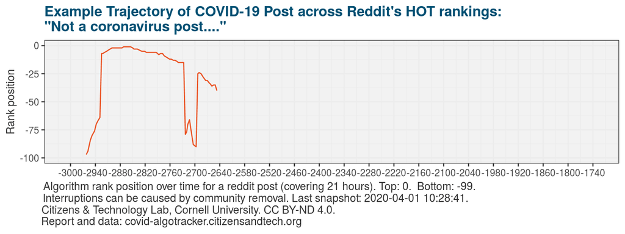

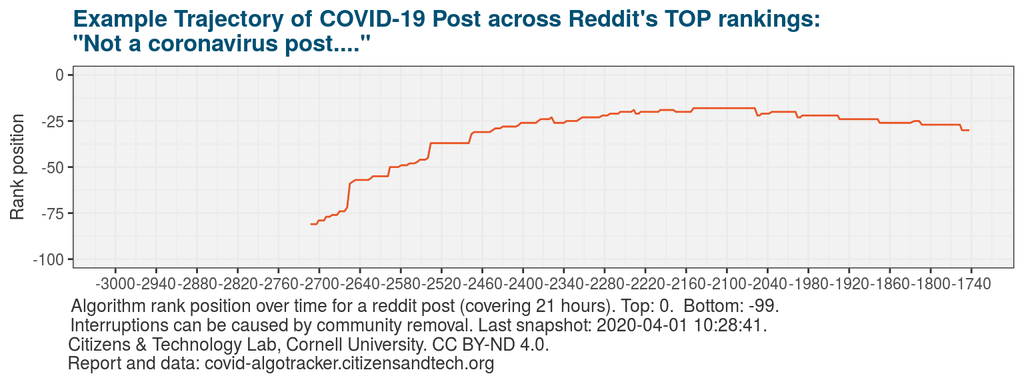

# Currently-Promoted COVID-19 Posts on Reddit

## Posts Currently Promoted by the HOT Algorithm

In the latest snapshot, 11.1% of posts appearing in the HOT algorithm on reddit are COVID-19 related.

- **(rank 0 to -99) (upvotes) (title)**
- ( 0)(🔺33861) **Pole dancers during quarantine**
  - **r/funny**. (💬1493) Domain: /r/funny/comments/fstpe7/pole_dancers_during_quarantine/. Highest Rank: 0. Time on hot: 43 minutes
- ( -7)(🔺21640) **My house burnt down just as quarantine started I lost my dog and my pc in the fire there was not much else in the room with the fire**
  - **r/Wellthatsucks**. (💬 748) Domain: v.redd.it. Highest Rank: -6. Time on hot: 192 minutes
- (-20)(🔺56922) **A Wuhan doctor who was among the first to alert other medics to the spread of coronavirus has disappeared sparking concerns that she has been detained**
  - **r/worldnews**. (💬2886) Domain: dailymail.co.uk. Highest Rank: -1. Time on hot: 364 minutes
- (-26)(🔺10951) **Trump just admitted he downplayed the threat of coronavirus: ‘I knew it could be horrible’**
  - **r/politics**. (💬 791) Domain: businessinsider.com. Highest Rank: -26. Time on hot: 120 minutes
- (-29)(🔺15793) **Police in El Salvador publicly shaming anyone caught violating the quarantine**
  - **r/PublicFreakout**. (💬 507) Domain: v.redd.it. Highest Rank: -23. Time on hot: 199 minutes
- (-31)(🔺77378) **Look! An ambulance caravan is on their way to New York to help out with the Coronavirus outbreak. God speed! 🇺🇸**
  - **r/gifs**. (💬2096) Domain: i.redd.it. Highest Rank: 0. Time on hot: 495 minutes
- (-36)(🔺11745) **COVID-19 companies that pretend to care about you starterpack**
  - **r/starterpacks**. (💬 206) Domain: i.redd.it. Highest Rank: -35. Time on hot: 223 minutes
- (-51)(🔺 4652) **Pentagon says it still hasn’t sent ventilators because it hasn’t been told where to send them**
  - **r/nottheonion**. (💬 218) Domain: cnn.com. Highest Rank: -51. Time on hot: 26 minutes
- (-60)(🔺 7147) **ULPT: a LOT of senior citizens are going to start dying with this new pandemic….**
  - **r/UnethicalLifeProTips**. (💬 622) Domain: self.UnethicalLifeProTips. Highest Rank: -47. Time on hot: 345 minutes
- (-87)(🔺 4010) **A quarantine is a great time to steal packages with your friends…**
  - **r/iamatotalpieceofshit**. (💬 113) Domain: i.redd.it. Highest Rank: -87. Time on hot: 4 minutes
- (-95)(🔺15202) **‘Dictatorships often start in the face of a threat’: UN privacy chief warns against long-lasting theft of freedoms amid coronavirus surveillance**
  - **r/Futurology**. (💬 495) Domain: independent.co.uk. Highest Rank: -47. Time on hot: 409 minutes

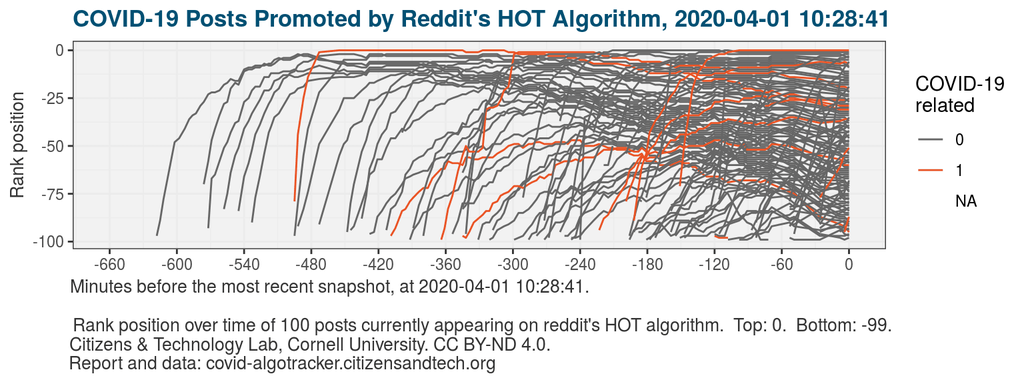

## Posts Currently Promoted by the TOP Algorithm

In the latest snapshot, 18.0% of posts appearing in the TOP algorithm on reddit are COVID-19 related.

- **(rank 0 to -99) (upvotes) (title)**
- ( -1)(🔺132220) **Robert Irwin with his isolation buddy.**
  - **r/pics**. (💬1352) Domain: i.redd.it. Highest Rank: 0. Time on top: 913 minutes
- ( -5)(🔺111242) **‘Dictatorships often start in the face of a threat’: UN privacy chief warns against long-lasting theft of freedoms amid coronavirus surveillance**
  - **r/worldnews**. (💬4484) Domain: independent.co.uk. Highest Rank: -4. Time on top: 796 minutes
- (-26)(🔺 77379) **Look! An ambulance caravan is on their way to New York to help out with the Coronavirus outbreak. God speed! 🇺🇸**
  - **r/gifs**. (💬2096) Domain: i.redd.it. Highest Rank: -26. Time on top: 314 minutes
- (-27)(🔺 75684) **Four zookeepers in Cornwall, UK, decided to self-isolate on the grounds of a wildlife sanctuary to make sure the animals are properly cared for during the coronavirus crisis.**
  - **r/worldnews**. (💬1165) Domain: metro.co.uk. Highest Rank: -21. Time on top: 1094 minutes
- (-37)(🔺 63219) **Elon Musk: We have extra FDA-approved ventilators. Will ship to hospitals worldwide within Tesla delivery regions. Device & shipping cost are free. Only requirement is that the vents are needed immediately for patients, not stored in a warehouse. Please me or @Tesla know.**
  - **r/Coronavirus**. (💬1729) Domain: media.discordapp.net. Highest Rank: -37. Time on top: 734 minutes
- (-39)(🔺 62300) **This pandemic is really bringing out the crazy.**
  - **r/insanepeoplefacebook**. (💬2351) Domain: i.redd.it. Highest Rank: -39. Time on top: 746 minutes
- (-40)(🔺 62007) **COvid-19 cautions.**
  - **r/funny**. (💬1112) Domain: i.redd.it. Highest Rank: -40. Time on top: 913 minutes
- (-47)(🔺 58209) **Anger is growing at China over COVID-19 and its apparent cover-up attempt**
  - **r/Coronavirus**. (💬 858) Domain: news.sky.com. Highest Rank: -47. Time on top: 376 minutes
- (-49)(🔺 57942) **Social Distancing drinking games in the wild**
  - **r/funny**. (💬 787) Domain: i.redd.it. Highest Rank: -49. Time on top: 495 minutes
- (-56)(🔺 55878) **Been in isolation 2 weeks, government say I must remain in isolation for 12 weeks except for essential appointments - today was chemo day. My dad bought me more craft supplies while I was at hospital. We came back to this…**
  - **r/Wellthatsucks**. (💬1034) Domain: i.redd.it. Highest Rank: -55. Time on top: 376 minutes
- (-57)(🔺 56926) **A Wuhan doctor who was among the first to alert other medics to the spread of coronavirus has disappeared sparking concerns that she has been detained**
  - **r/worldnews**. (💬2886) Domain: dailymail.co.uk. Highest Rank: -57. Time on top: 72 minutes
- (-66)(🔺 51468) **Quarantine life…**
  - **r/memes**. (💬 168) Domain: i.redd.it. Highest Rank: -65. Time on top: 873 minutes
- (-67)(🔺 51530) **The longer this quarantine goes on, the more I feel like a laid off David Wallace**
  - **r/DunderMifflin**. (💬 425) Domain: i.redd.it. Highest Rank: -67. Time on top: 314 minutes
- (-72)(🔺 48543) **Elon Musk announces free delivery of FDA-approved ventilators to hospitals worldwide**
  - **r/UpliftingNews**. (💬2431) Domain: mystateline.com. Highest Rank: -72. Time on top: 192 minutes
- (-80)(🔺 46369) **I can’t learn while in quarantine..**
  - **r/memes**. (💬 280) Domain: i.redd.it. Highest Rank: -79. Time on top: 492 minutes
- (-83)(🔺 45324) **Our son’s hair was in desperate need of a haircut during quarantine. Husband and I took a wack at it. We had to stop before it got worse.**
  - **r/therewasanattempt**. (💬1751) Domain: i.redd.it. Highest Rank: -79. Time on top: 675 minutes
- (-85)(🔺 45182) **I call this the break quarantine challenge**
  - **r/Tinder**. (💬 422) Domain: i.redd.it. Highest Rank: -81. Time on top: 662 minutes
- (-96)(🔺 42173) **I hate quarantine**
  - **r/teenagers**. (💬 319) Domain: i.redd.it. Highest Rank: -95. Time on top: 568 minutes

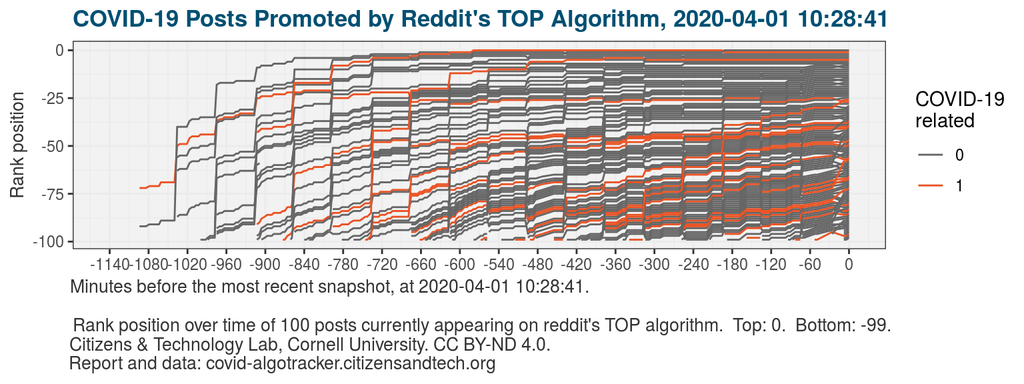

# Top Communities Promoted by Reddit’s Algorithms

Reddit’s algorithms recommended these subreddits at least 3 times over the last 3 days.

Top **subreddit communities** with COVID-19 content promoted by reddit’s algorithms in the past 3 days.

|  | frequency |
| --- | --- |
| Coronavirus | 20 |
| politics | 20 |
| worldnews | 20 |
| funny | 11 |
| pics | 9 |
| gifs | 5 |
| memes | 5 |
| nba | 4 |
| Unexpected | 4 |
| UpliftingNews | 4 |
| insaneparents | 3 |
| news | 3 |
| nextfuckinglevel | 3 |
| tifu | 3 |
| videos | 3 |
| Wellthatsucks | 3 |

# Top domains Promoted by Reddit’s Algorithms

These domains were recommended at least 3 times by HOT or TOP over the last 3 days.

Top **web domains** with COVID-19 content promoted by reddit’s algorithms in the past 3 days.

|  | frequency |
| --- | --- |
| i.redd.it | 68 |
| v.redd.it | 12 |
| i.imgur.com | 10 |
| independent.co.uk | 8 |
| businessinsider.com | 4 |
| cbc.ca | 3 |
| cnn.com | 3 |
| self.tifu | 3 |
| theweek.com | 3 |
| youtube.com | 3 |

# Ethics

This dashboard summarizes and archives information that is currently public on reddit’s front page. To reduce risks to communities, this dashboard does not link directly to discussions. All author information is removed from the archival datasets.

You can read more about CAT Lab’s ethics values and processes in our post on [strategies for ethical, accountable online behavior research](https://medium.com/@natematias/3-strategies-for-accountable-ethical-online-behavioral-research-f6ae134458fc).

# Questions and Bugs

If you find a bug or have a question, please [post it to the issues page](https://github.com/natematias/covid-algotracker/issues) for this project on github. Thanks!

# About CAT Lab

The [Citizens and Technology Lab](https://citizensandtech.org) at Cornell University with communities to study the social impacts of digital technologies and discover effective ideas for change. CAT Lab is led by [Dr. J. Nathan Matias](https://natematias.com), an assistant professor in the department of Communication.

Working alongside communities and volunteers, we discover practical knowledge that also contributes to science, holds companies accountable, and is guided by the people most affected. Communities bring their problems, deep knowledge, and desire for change. We bring expertise in scientific research and a software platform for coordinating citizen behavioral science.

Over a dozen communities with tens of millions of people have worked with CAT Lab since 2016 on reddit, Wikipedia, and Twitter. We have tested practical ways to prevent harassment, fight misinformation, broaden inclusion, manage civic discourse, and protect freedom of expression. Our discoveries have directly influenced community practice, corporate policies, and government discussions worldwide. These [industry-independent](https://citizensandtech.org/2020/01/industry-independent-research/) findings are regularly published by the world’s top scientific journals in the social sciences and computer science.

# References and Further Reading

- Leavitt, A., & Robinson, J. J. (2017). [Upvote My News: The Practices of Peer Information Aggregation for Breaking News on reddit.com](https://dl.acm.org/doi/abs/10.1145/3134700). Proceedings of the ACM on Human-Computer Interaction, 1(CSCW), 1-18.
- Leavitt, A., & Robinson, J. J. (2017, February). [The role of information visibility in network gatekeeping: Information aggregation on Reddit during crisis events](https://dl.acm.org/doi/pdf/10.1145/2998181.2998299). In Proceedings of the 2017 ACM conference on computer supported cooperative work and social computing (pp. 1246-1261).
- Larson, H. J. (2018). [The biggest pandemic risk? Viral misinformation](https://www.nature.com/articles/d41586-018-07034-4). Nature, 562(7726), 309-310.
- Matias, J. N. (2019). [Preventing harassment and increasing group participation through social norms in 2,190 online science discussions](https://www.pnas.org/content/early/2019/04/23/1813486116). Proceedings of the National Academy of Sciences, 116(20), 9785-9789.
- Matias, J. N. (pre-print, 2018). [Nudging Algorithms by Influencing Human Behavior. Effects of Encouraging Fact-Checking on News Algorithms](https://osf.io/m98b6/). https://osf.io/m98b6/
- Matias, J. N., & Mou, M. (2018, April). [CivilServant: Community-led experiments in platform governance](https://natematias.com/media/Community_Led_Experiments-CHI_2018.pdf). In Proceedings of the 2018 CHI conference on human factors in computing systems (pp. 1-13).
- Vaughan, E., & Tinker, T. (2009). [Effective health risk communication about pandemic influenza for vulnerable populations](https://www.ncbi.nlm.nih.gov/pmc/articles/PMC4504362/). American Journal of Public Health, 99(S2), S324-S332.